# Lab 4: Binary Logistic Regression — Model Specification, Comparison, and Interpretation

- Show All Code
- Hide All Code
- View Source

Which passenger characteristics predict surviving the sinking of the Titanic?

Author

Sanjivan Loganathan

Published

November 13, 2026

## Overview

This report investigates which passenger characteristics were associated with surviving the sinking of the Titanic.

## Part 1: Load packages and prepare the data

### 1.2 Packages

Install any missing packages once in the R Console:

```r
# Console
install.packages(c(
  "glmmTMB", "dplyr", "tidyr", "ggplot2",
  "broom.mixed", "performance", "gt", "readr",
  "DHARMa", "ggeffects", "titanic"))
```

### 1.3 The dataset

```r
library(glmmTMB)
library(dplyr)
library(tidyr)
library(ggplot2)
library(broom.mixed)
library(performance)
library(gt)
library(readr)
library(DHARMa)
library(ggeffects)
library(titanic)

titanic <- titanic_train

#Keep the same complete-case sample for every model
titanic <- titanic |>
  select(Survived, Sex, Age, Pclass) |>
  drop_na() |>
  mutate(
    Sex.Binary = case_when(
      Sex == "male" ~ 0,
      Sex == "female" ~ 1)) |>
  mutate(
    Survived.Char = case_when(
      Survived == 0 ~ "Died",
      Survived == 1 ~ "Survived")) |>
  mutate(
    Pclass.Char = case_when(
      Pclass == "1" ~ "First Class",
      Pclass == "2" ~ "Second Class",
      Pclass == "3" ~ "Third Class")) |>
  mutate(Pclass = factor(Pclass, levels = c(1, 2, 3))) |>
  select(Survived, Survived.Char, Sex, Sex.Binary, Pclass, Pclass.Char, Age)

n <- nrow(titanic)
```

The `titanic_train` dataset contains 891 passengers. Removing the passengers with no recorded age leaves 714 passengers, and every model below is estimated on this sample.

| Variable | Description | Role |
| --- | --- | --- |
| `Survived` | Whether a passenger survived (1) or died (0) in the crash | Outcome |
| `Sex` | Sex reported on legal documents | Predictor |
| `Age` | Self-reported age in years | Predictor |
| `Pclass` | Ticket class (first, second or third); which acts our proxy for socioeconomic status (SES) | Predictor |

R orders text categories alphabetically, so **female** is the reference group for `Sex` and the coefficient `Sexmale` compares males with females. For `Pclass`, **first class** is the reference group.

### 1.4 Exploring the data

```r
# Console
head(titanic)
str(titanic)
summary(titanic$Age)
hist(titanic$Age)
table(titanic$Survived.Char)
table(titanic$Sex, titanic$Survived.Char)
table(titanic$Pclass.Char, titanic$Survived.Char)
```

#### Descriptive statistics

```r
#descriptive stats, mean, sd, range
descriptives <- titanic |>
  summarise(
    across(
      c(Age),
      list(mean = mean, sd = sd, min = min, max = max)
    )
  ) |>
  pivot_longer(
    everything(),
    names_to = c("variable", ".value"),
    names_sep = "_"
  )

descriptives |>
  gt() |>
  fmt_number(columns = where(is.numeric), decimals = 2)
```

| variable | mean | sd | min | max |
| --- | --- | --- | --- | --- |
| Age | 29.70 | 14.53 | 0.42 | 80.00 |

#### Survived

```r
#counts for survived
titanic |>
  count(Survived.Char) |>
  gt()
```

| Survived.Char | n |
| --- | --- |
| Died | 424 |
| Survived | 290 |

#### Sex

```r
#counts for sex
titanic |>
  count(Sex) |>
  gt()
```

| Sex | n |
| --- | --- |
| female | 261 |
| male | 453 |

#### Ticket class

```r
#counts for class
titanic |>
  count(Pclass.Char) |>
  gt()
```

| Pclass.Char | n |
| --- | --- |
| First Class | 186 |
| Second Class | 173 |
| Third Class | 355 |

#### Survival by sex and ticket class

```r
#outcome broken down by groups
titanic |>
  count(Sex, Pclass.Char, Survived.Char) |>
  pivot_wider(names_from = Survived.Char, values_from = n) |>
  gt()
```

| Sex | Pclass.Char | Died | Survived |
| --- | --- | --- | --- |
| female | First Class | 3 | 82 |
| female | Second Class | 6 | 68 |
| female | Third Class | 55 | 47 |
| male | First Class | 61 | 40 |
| male | Second Class | 84 | 15 |
| male | Third Class | 215 | 38 |

#### Patterns in the data

Of the 714 passengers, 290 (41%) survived and 424 died. The outcome is therefore unbalanced, but both outcomes are common. Passengers were 29.7 years old on average (*SD* = 14.5), ranging from infants under one year old to 80.

The categorical variables are not evenly distributed. There are almost twice as many men (453) as women (261), and half of the passengers held third-class tickets (355), with the remaining first (186) and second class (173) roughly equal in size. None of these groups are small, though, so there are enough passengers in each to estimate its survival rate.

Survival differs sharply by sex and class, as expected (see Part 2.1). 75% of women survived compared with only 21% of men. Survival also falls with ticket class: 66% in first class, 48% in second class and 24% in third class. Children under 18 survived more often (54%) than adults (38%).

The cross-tabulation shows that the two predictors combine: almost every woman in first and second class survived, while most men in second and third class died. One pattern that was not expected is that the female advantage is much smaller in third class, where only about half of the women survived. A few cells are also very small (only 3 first-class women died), which informs checks for seperation in Part 4.

## Part 2: Competing logistic regression models

### 2.1 Predictions

**Sex.** As officers loading the lifeboats generally followed the convention of “women and children first”, it is expected for women to have much higher odds of survival than men, and sex to be the strongest of the three predictors.

**Ticket class (SES).** The lifeboats had room for only about half of the people on board, so getting to a boat early was crucial. First-class cabins were closest to the lifeboats and likely tended to more by crew. Third-class passengers were lower in the ship. Therefore, it is expected for survival to decrease from first to second to third class, even after accounting for sex.

**Age.** As children were also given priority and older passengers are less likely to withstand the conditions. It is expected that younger passengers to have higher odds of survival. Since, the priority applied to children rather than to age in general, age is likely the weakest of the predictors.

These predictions motivate a sequence that adds the predictors in order of their expected importance: sex first, then ticket class, then age.

### 2.2 Four nested models

| Model | Formula | Purpose |
| --- | --- | --- |
| mod0: Null | `Survived ~ 1` | Establish a baseline |
| mod1: Sex | `Survived ~ Sex` | Evaluate sex |
| mod2: + Pclass | `Survived ~ Sex + Pclass` | Evaluate the additional contribution of ticket class |
| mod3: + Age | `Survived ~ Sex + Pclass + Age` | Evaluate the additional contribution of age |

The models are nested: each one contains all the predictors of the model before it, plus one more.

```r
mod0 <- glmmTMB(
  Survived ~ 1,
  data = titanic,
  family = binomial(link = "logit"))

mod1 <- glmmTMB(
  Survived ~ Sex,
  data = titanic,
  family = binomial(link = "logit"))

mod2 <- glmmTMB(
  Survived ~ Sex + Pclass,
  data = titanic,
  family = binomial(link = "logit"))

mod3 <- glmmTMB(
  Survived ~ Sex + Pclass + Age,
  data = titanic,
  family = binomial(link = "logit"))
```

### 2.3 Exploring the fitted models

```r
# Console
summary(mod0)
summary(mod1)
summary(mod2)
summary(mod3)
```

In every model, all coefficients are in the predicted direction: men, second- and third-class passengers, and older passengers have lower log-odds of survival.

**The intercept** The intercept is the log-odds of survival for a passenger in the reference group of every predictor, so its meaning changes each time a predictor is added:

- **mod1:** the intercept (1.12) is the log-odds of survival for **women**. This is a probability of 0.75, which equals the observed survival rate for women.
- **mod2:** the intercept (2.33) is the log-odds of survival for **women in first class** (probability = 0.91).
- **mod3:** the intercept (3.78) is the log-odds of survival for **women in first class aged 0** (probability = 0.98). Age 0 sits at the very edge of the data (the youngest passenger was 0.42 years old), so this value describes a newborn and mainly serves to position the model.

The intercept rises at each step because the reference group becomes a narrower, more advantaged subgroup of passengers.

**How the other coefficients change.** The sex coefficient barely changes across models (-2.48, -2.57, -2.52), so the sex difference is not explained by class or age. The class coefficients, however, become larger when age is added (third class: -1.97 in mod2 vs. -2.58 in mod3). First-class passengers were older on average (38 years, compared with 25 in third class), and older age lowers survival. Without age in the model, part of the first-class advantage was hidden by their older age.

## Part 3: Model comparison

### 3.1 Nested-model χ²-tests

```r
tests <- anova(mod0, mod1, mod2, mod3)

tests
```

```
Data: titanic
Models:
mod0: Survived ~ 1, zi=~0, disp=~1
mod1: Survived ~ Sex, zi=~0, disp=~1
mod2: Survived ~ Sex + Pclass, zi=~0, disp=~1
mod3: Survived ~ Sex + Pclass + Age, zi=~0, disp=~1
     Df    AIC    BIC  logLik deviance   Chisq Chi Df Pr(>Chisq)
mod0  1 966.52 971.09 -482.26   964.52
mod1  2 754.70 763.84 -375.35   750.70 213.816      1  < 2.2e-16 ***
mod2  4 680.43 698.71 -336.22   672.43  78.269      2  < 2.2e-16 ***
mod3  5 657.28 680.14 -323.64   647.28  25.148      1  5.311e-07 ***
---
Signif. codes:  0 '***' 0.001 '**' 0.01 '*' 0.05 '.' 0.1 ' ' 1
```

Each row after the first tests whether that model improves fit relative to the model before it.

```r
# anova() for glmmTMB reports the number of parameters (Df) rather than the
# residual df, so the residual df are taken from glance() in 3.2 instead
tests <- tests |>
  select(Chisq, `Chi Df`, `Pr(>Chisq)`) |>
  rename(
    Nested.df = `Chi Df`,
    Nested.Chisq.stat = Chisq,
    Nested.p.value = `Pr(>Chisq)`)
```

1. **Does sex explain significantly more variation than the intercept-only model?** Yes: χ²(1) = 213.82, *p* < .001.
2. **Does adding ticket class improve fit beyond sex?** Yes: χ²(2) = 78.27, *p* < .001.
3. **Does adding age improve fit beyond sex and ticket class?** Yes: χ²(1) = 25.15, *p* < .001.

### 3.2 Model-level performance

```r
glance0 <- broom.mixed::glance(mod0)
glance1 <- broom.mixed::glance(mod1)
glance2 <- broom.mixed::glance(mod2)
glance3 <- broom.mixed::glance(mod3)

mods <- c(
  "mod0: Null",
  "mod1: Sex",
  "mod2: + Pclass",
  "mod3: + Age")

glances <- rbind(
  glance0,
  glance1,
  glance2,
  glance3)
```

### 3.3 Combined model-comparison table

Because the rows in `glances` and `tests` represent the same models in the same order, they can be combined using `cbind()`.

```r
comparison_table <- cbind(
  Model = mods,
  glances,
  tests)
```

```r
comparison_table |>
  select(
    Model,
    AIC,
    BIC,
    logLik,
    deviance,
    df.residual,
    Nested.df,
    Nested.Chisq.stat,
    Nested.p.value
  ) |>
  gt() |>
  cols_label(
    Model = "Model",
    AIC = "AIC",
    BIC = "BIC",
    logLik = "Log-likelihood",
    deviance = "Deviance",
    df.residual = "Residual df",
    Nested.df = "Nested df",
    Nested.Chisq.stat = "Nested χ²",
    Nested.p.value = "Nested p"
  ) |>
  fmt_number(
    columns = c(
      AIC,
      BIC,
      logLik,
      deviance,
      Nested.Chisq.stat
    ),
    decimals = 2
  ) |>
  fmt(
    columns = Nested.p.value,
    fns = function(x) {
      ifelse(
        is.na(x),
        "—",
        ifelse(x < .001, "< .001", sprintf("%.3f", x))
      )
    }
  ) |>
  sub_missing(
    columns = c(Nested.df, Nested.Chisq.stat),
    missing_text = "—"
  )
```

| Model | AIC | BIC | Log-likelihood | Deviance | Residual df | Nested df | Nested χ² | Nested p |
| --- | --- | --- | --- | --- | --- | --- | --- | --- |
| mod0: Null | 966.52 | 971.09 | −482.26 | 964.52 | 713 | — | — | — |
| mod1: Sex | 754.70 | 763.84 | −375.35 | 750.70 | 712 | 1 | 213.82 | < .001 |
| mod2: + Pclass | 680.43 | 698.71 | −336.22 | 672.43 | 710 | 2 | 78.27 | < .001 |
| mod3: + Age | 657.28 | 680.14 | −323.64 | 647.28 | 709 | 1 | 25.15 | < .001 |

### 3.4 Interpreting the comparisons

**Which model fits best?** mod3 has both the lowest AIC (657.28) and the lowest BIC (680.14). Even though it is the most complex model, it provides the best balance between fit and complexity.

**How do AIC and BIC change?** Both fall at every step. The largest drop comes from adding sex (AIC falls by 211.8), followed by ticket class (74.3) and then age (23.1). BIC falls slightly less than AIC at each step because it penalizes each extra parameter by log(*n*) = 6.57 instead of 2.

**Which additions significantly improve fit?** All three. Sex produces by far the largest improvement (χ² = 213.82), ticket class a large improvement (χ² = 78.27 on 2 df), and age a smaller but still clear improvement (χ² = 25.15), all *p* < .001.

**Do AIC and BIC agree with the likelihood-ratio tests?** Yes. The three criteria agree here because each improvement in fit is much larger than the penalty for the added parameters. For example, adding age reduces the deviance by 25.15 for one extra parameter, far more than the AIC penalty (2) or the BIC penalty (6.57). The criteria could disagree for a predictor with a small but significant improvement (a χ² between 3.84 and 6.57 on 1 df), where the likelihood-ratio test would favour adding it but BIC would not.

**What the pattern says about each predictor.** Sex is the dominant predictor of survival. Ticket class adds substantial information beyond sex, and age adds a smaller but reliable amount beyond both. Each predictor therefore captures something about survival that the others do not, and mod3 is the most promising model to carry forward.

## Part 4: Logistic regression diagnostics

### 4.1 Provisional model selection

The most complex model whose likelihood-ratio test is still significant is provisionally selected.

```r
selected_row <- comparison_table |>
  filter(Nested.p.value < .05) |>
  slice_tail(n = 1)

#creating an object with our selected model's name for dynamic reporting
selected_name <- selected_row$Model

#case matching for dynamic reporting
selected_model <- switch(
  selected_name,
  "mod0: Null" = mod0,
  "mod1: Sex" = mod1,
  "mod2: + Pclass" = mod2,
  "mod3: + Age" = mod3)
```

The provisionally selected model is **mod3: + Age**.

#### Linearity on the logit scale

```r
set.seed(9041)
res_selected <- simulateResiduals(selected_model, n = 500, plot = FALSE)
```

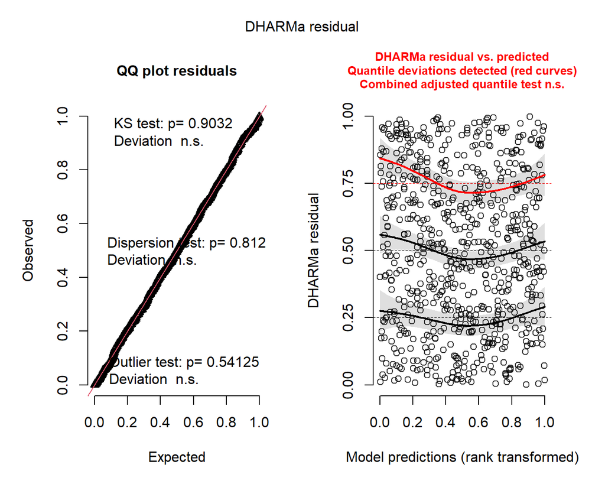

```r
plot(res_selected)
```

Because age is the only continuous predictor, I also plot the residuals against age to check that a straight line on the logit scale is adequate.

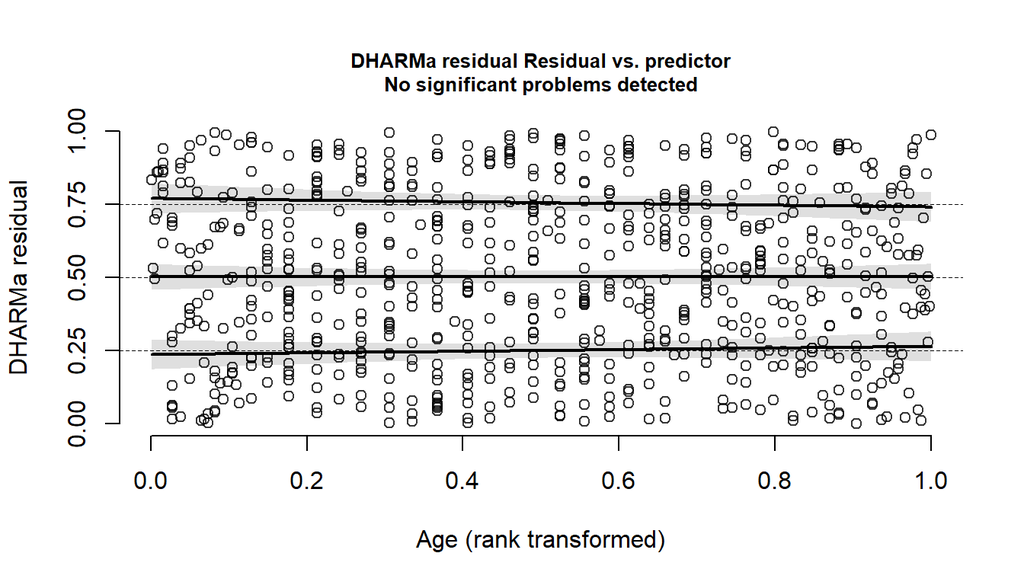

```r
plotResiduals(res_selected, form = titanic$Age)
```

#### Collinearity

```r
check_collinearity(selected_model)
```

```
# Check for Multicollinearity

Low Correlation

   Term  VIF   VIF 95% CI adj. VIF Tolerance Tolerance 95% CI
    Sex 1.07 [1.02, 1.23]     1.04      0.93     [0.81, 0.98]
 Pclass 1.42 [1.30, 1.57]     1.09      0.71     [0.64, 0.77]
    Age 1.33 [1.23, 1.48]     1.15      0.75     [0.68, 0.81]
```

#### Complete separation

```r
# Fitted probabilities of exactly 0 or 1 would be a symptom of separation
range(fitted(selected_model))
```

```
[1] 0.01690156 0.97594452
```

#### Influential observations

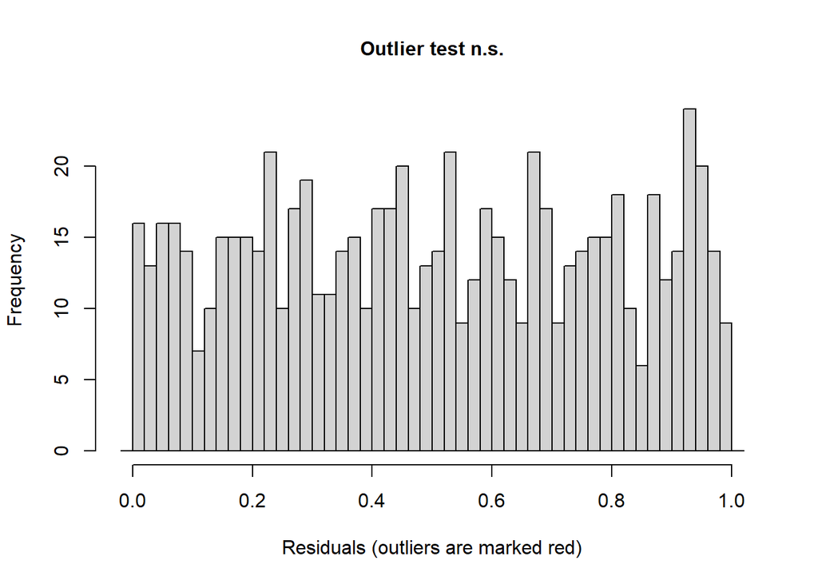

```
    DHARMa outlier test based on exact binomial test with approximate
    expectations

data:  res_selected
outliers at both margin(s) = 1, observations = 714, p-value = 0.5412
alternative hypothesis: true probability of success is not equal to 0.003992016
95 percent confidence interval:
 3.545849e-05 7.778486e-03
sample estimates:
frequency of outliers (expected: 0.00399201596806387 )
                                            0.00140056
```

```r
testOutliers(res_selected)
```

#### Events per predictor

```r
n_event <- sum(titanic$Survived == 1)
n_nonevent <- sum(titanic$Survived == 0)
n_coef <- length(fixef(selected_model)$cond)
```

### 4.2 Diagnostic findings

**Linearity on the logit scale.** The DHARMa residuals behave as expected for a well-specified model. In the Q–Q plot the residuals lie along the diagonal, and neither the uniformity test (*p* = 0.9) nor the dispersion test (*p* = 0.81) is significant. In the residuals-versus-predicted plot, the median and lower quantile lines stay close to their expected values, but DHARMa flags the upper (0.75) quantile line in red. It bends upward at both ends of the predicted range. However, the combined test across all three quantiles is not significant (*p* = 0.083), so this is a mild pattern rather than a clear violation, and the residual variability is reasonably uniform overall. The pattern may reflect structure that a main-effects model cannot capture, such as the sex-by-class pattern noted in Part 1. The residuals are flat across age, and no problems are detected there, so treating age as linear on the logit scale appears adequate.

**Collinearity.** All variance inflation factors are low (the largest is 1.42). Class and age are related, as noted in Part 2.3, but not strongly enough to make their unique contributions hard to estimate.

**Complete separation.** There are no symptoms of separation: the model converged without warnings, no coefficient or standard error is unusually large (see the table in 5.2), and the fitted probabilities range from 0.017 to 0.976, never reaching 0 or 1.

**Influential observations.** The DHARMa outlier test is not significant (*p* = 0.54), so no passengers are unusually poorly predicted.

**Events per predictor.** There are 290 survivors and 424 deaths for 5 coefficients, or about 58 events per coefficient. This is well above the rough minimum of 10, so the coefficients should be estimated with reasonable precision.

**What this means for the findings.** The diagnostics give no serious reason to doubt mod3, so the standard errors, confidence intervals and *p*-values can be treated as reasonably trustworthy. The main caveat is what the model leaves out, which the one flagged quantile line also hints at. It contains only main effects, so it assumes that, for example, the female advantage is the same size (on the log-odds scale) in every ticket class. The cross-tabulation in Part 1 suggests that the female advantage may be smaller in third class. The odds ratios below should therefore be read as average associations across the passengers.

## Part 5: The preferred model

### 5.1 Model selection

I select **mod3 (sex + ticket class + age)** as the most defensible model. Every criterion points the same way:

- **Nested χ²-tests:** each predictor, including age, significantly improves fit over the model before it.
- **AIC and BIC:** mod3 has the lowest value on both, so the improvement from adding age outweighs even BIC’s stronger penalty for complexity.
- **Complexity:** mod3 has only 5 coefficients for 290 survivors, so it is not overfitted.
- **Diagnostics:** its assumptions are reasonably satisfied, with only a mild residual pattern and no collinearity, separation or influential observations.
- **Interpretability:** each coefficient corresponds directly to one of my predictions.

A simpler model would also give a misleading picture. Dropping age would remove a reliable predictor and, as shown in Part 2.3, would understate how much ticket class mattered.

### 5.2 Coefficient table

```r
coefficient_results <- broom.mixed::tidy(
  selected_model,
  effects = "fixed",
  component = "cond",
  conf.int = TRUE,
  conf.level = 0.95)

# Exponentiate the log-odds and their CI limits to get odds ratios
coefficient_results <- coefficient_results |>
  mutate(
    odds.ratio = exp(estimate),
    or.conf.low = exp(conf.low),
    or.conf.high = exp(conf.high))
```

```r
coefficient_results |>
  select(
    term,
    estimate,
    std.error,
    conf.low,
    conf.high,
    p.value,
    odds.ratio,
    or.conf.low,
    or.conf.high
  ) |>
  gt() |>
  cols_label(
    term = "Predictor",
    estimate = "Estimate",
    std.error = "SE",
    conf.low = "95% CI lower",
    conf.high = "95% CI upper",
    p.value = "p",
    odds.ratio = "Odds ratio",
    or.conf.low = "95% CI lower",
    or.conf.high = "95% CI upper"
  ) |>
  tab_spanner(
    label = "Log-odds",
    columns = c(estimate, std.error, conf.low, conf.high, p.value)
  ) |>
  tab_spanner(
    label = "Odds ratio",
    columns = c(odds.ratio, or.conf.low, or.conf.high)
  ) |>
  fmt_number(
    columns = c(
      estimate,
      std.error,
      conf.low,
      conf.high,
      odds.ratio,
      or.conf.low,
      or.conf.high
    ),
    decimals = 3
  ) |>
  fmt(
    columns = p.value,
    fns = function(x) {
      ifelse(
        x < .001,
        "< .001",
        sprintf("%.3f", x)
      )
    }
  )
```

| Predictor | Log-odds Estimate | Log-odds SE | Log-odds 95% CI lower | Log-odds 95% CI upper | Log-odds p | Odds ratio | Odds ratio 95% CI lower | Odds ratio 95% CI upper |
| --- | --- | --- | --- | --- | --- | --- | --- | --- |
| (Intercept) | 3.777 | 0.401 | 2.991 | 4.563 | < .001 | 43.685 | 19.902 | 95.888 |
| Sexmale | −2.523 | 0.207 | −2.929 | −2.116 | < .001 | 0.080 | 0.053 | 0.120 |
| Pclass2 | −1.310 | 0.278 | −1.855 | −0.765 | < .001 | 0.270 | 0.156 | 0.465 |
| Pclass3 | −2.581 | 0.281 | −3.132 | −2.029 | < .001 | 0.076 | 0.044 | 0.131 |
| Age | −0.037 | 0.008 | −0.052 | −0.022 | < .001 | 0.964 | 0.949 | 0.978 |

### 5.3 Interpreting the coefficients

```r
# One row per predictor, for the inline values in the text below
int_coef <- coefficient_results |> filter(term == "(Intercept)")
sex_coef <- coefficient_results |> filter(term == "Sexmale")
class2_coef <- coefficient_results |> filter(term == "Pclass2")
class3_coef <- coefficient_results |> filter(term == "Pclass3")
age_coef <- coefficient_results |> filter(term == "Age")
```

**Sex.** Holding ticket class and age constant, the **log-odds** of survival for men are 2.52 lower than for women, 95% CI [-2.93, -2.12]. As an **odds ratio**, men had 0.08 times the odds of surviving that women had, 95% CI [0.05, 0.12], which is about 92% lower odds. Put the other way, women had about 12.5 times the odds of survival of men of the same class and age.

**Ticket class.** Holding sex and age constant, the **log-odds** of survival for second-class passengers are 1.31 lower than for first-class passengers, 95% CI [-1.85, -0.76], and for third-class passengers they are 2.58 lower, 95% CI [-3.13, -2.03]. As **odds ratios**, second-class passengers had 0.27 times the odds of survival of first-class passengers, 95% CI [0.16, 0.47], and third-class passengers had 0.08 times the odds, 95% CI [0.04, 0.13]. In other words, a first-class passenger had about 13.2 times the odds of survival of a third-class passenger of the same sex and age.

**Age.** Holding sex and ticket class constant, each additional year of age is associated with a decrease of 0.037 in the **log-odds** of survival, 95% CI [-0.052, -0.022]. As an **odds ratio**, each additional year multiplies the odds of survival by 0.964, 95% CI [0.949, 0.978], or about 3.6% lower odds per year. This adds up over a lifetime: a passenger 10 years older had 0.69 times the odds of survival of an otherwise similar passenger.

**Intercept.** The intercept (3.78) is the log-odds of survival for a first-class woman aged 0, which corresponds to odds of 43.69 to 1. As noted in Part 2.3, this is at the edge of the data and is not meaningful on its own.

**What is held constant.** Each coefficient compares passengers who are identical on the other two predictors. For example, the sex coefficient compares a man and a woman of the same age in the same ticket class. Because the model has no interactions, each odds ratio is the same regardless of the values of the other predictors. The difference in *probability* of survival is not constant, however, because it depends on a passenger’s starting probability (see 5.6).

### 5.4 Overall model performance

```r
selected_row |>
  select(
    Model,
    AIC,
    BIC,
    logLik,
    deviance,
    df.residual,
    Nested.df,
    Nested.Chisq.stat,
    Nested.p.value
  ) |>
  gt() |>
  cols_label(
    Model = "Model",
    AIC = "AIC",
    BIC = "BIC",
    logLik = "Log-likelihood",
    deviance = "Deviance",
    df.residual = "Residual df",
    Nested.df = "Nested df",
    Nested.Chisq.stat = "Nested χ²",
    Nested.p.value = "Nested p"
  ) |>
  fmt_number(
    columns = c(AIC, BIC, logLik, deviance, Nested.Chisq.stat),
    decimals = 2
  ) |>
  fmt(
    columns = Nested.p.value,
    fns = function(x) ifelse(x < .001, "< .001", sprintf("%.3f", x))
  )
```

| Model | AIC | BIC | Log-likelihood | Deviance | Residual df | Nested df | Nested χ² | Nested p |
| --- | --- | --- | --- | --- | --- | --- | --- | --- |
| mod3: + Age | 657.28 | 680.14 | −323.64 | 647.28 | 709 | 1 | 25.15 | < .001 |

The selected model has AIC = 657.28 and BIC = 680.14, compared with 966.52 and 971.09 for the null model. Its deviance (647.28) is 317.23 lower than the null model’s, and adding age in the final step significantly improved fit, χ²(1) = 25.15, *p* < .001.

### 5.5 Summary of results

> Four nested binary logistic regression models (binomial family, logit link) were fit to predict the survival of the Titanic sinking for 714 passengers with complete data, adding sex, ticket class and age in turn. Each predictor significantly improved model fit, and the full model had the lowest AIC and BIC. Its diagnostics showed no serious violations of the model’s assumptions. In the full model, men had much lower odds of survival than women, OR = 0.08, 95% CI [0.05, 0.12]. Compared with first-class passengers, second-class passengers had lower odds of survival, OR = 0.27, 95% CI [0.16, 0.47], and third-class passengers had even lower odds, OR = 0.08, 95% CI [0.04, 0.13]. Older passengers had lower odds of survival, OR = 0.964 per year of age, 95% CI [0.949, 0.978]. Each association holds the other two predictors constant.

### 5.6 Visualizing age as predicted probabilities

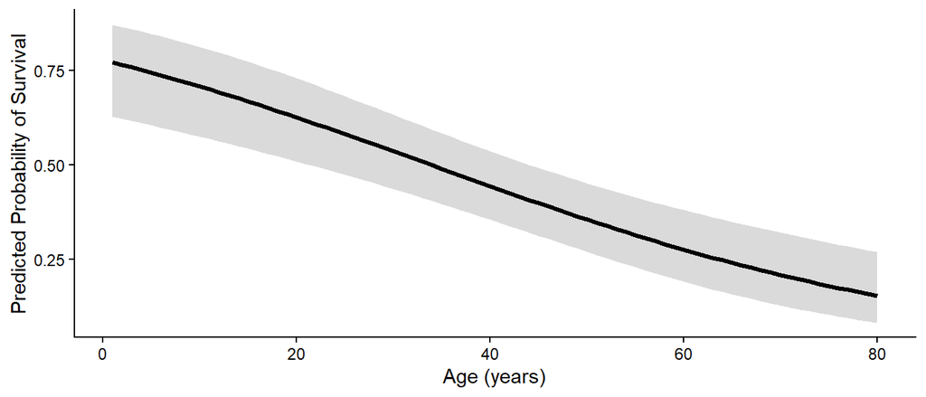

```r
pred_age <- ggpredict(selected_model, terms = "Age [1:80 by=1]")

ggplot(pred_age, aes(x, predicted)) +
  geom_ribbon(aes(ymin = conf.low, ymax = conf.high), alpha = 0.18) +
  geom_line(linewidth = 1.2) +
  labs(
    x = "Age (years)",
    y = "Predicted Probability of Survival"
  ) +
  theme_classic()
```

`ggpredict()` holds the other predictors fixed: ticket class at its reference level (first class) and, because `Sex` is stored as text, sex at its most common value (male). The plot therefore shows the predicted probability of survival for a **first-class man** at each age. The probability falls steadily with age, from about 0.77 for a one-year-old to about 0.15 for an 80-year-old. The confidence band is narrowest around the average age, where most of the data are, and widens at the extremes.

## Part 6: Discussion and limitations

**The relative importance of sex, ticket class and age.** Sex was the most important predictor of survival. It produced by far the largest improvement in model fit, and women had about 12.5 times the odds of surviving of men of the same class and age. This is consistent with the “women and children first” convention being applied during the evacuation. Ticket class was the second most important predictor, and its effect was large. The gap between first and third class (OR = 0.08) is similar in size to the gap between men and women (OR = 0.08). Sex still improves fit more because it divides all passengers into two large groups, while the largest class difference is only between first and third class. Age was the weakest predictor, with a small per-year effect that nevertheless adds up across the lifespan. Together, these results support all three predictions for being female, a child, and in first class improving survival.

**Limitations.**

- **Missing data.** The 177 passengers with no recorded age were excluded. If whether a passenger’s age was recorded is related to their class or their survival, the estimates may be biased.
- **The sample.** `titanic_train` is only a subset of the passengers, and it includes no crew, so the results may not generalize to everyone on board.
- **Main effects only.** The model assumes that the effect of sex is the same in each ticket class, but the cross-tabulation suggests that the female advantage was smaller in third class. A sex × class interaction would be worth testing.